## Regression Models Project

#### Context

You work for Motor Trend, a magazine about the automobile industry. Looking at a data set of a collection of cars, they are interested in exploring the relationship between a set of variables and miles per gallon (MPG) (outcome). They are particularly interested in the following two questions:

- “Is an automatic or manual transmission better for MPG”
- “Quantify the MPG difference between automatic and manual transmissions”

#### Question

Take the mtcars data set and write up an analysis to answer their question using regression models and exploratory data analyses.

Your report must be:

- Written as a PDF printout of a compiled (using knitr) R markdown document.
- Brief. Roughly the equivalent of 2 pages or less for the main text. Supporting figures in an appendix can be included up to 5 total pages including the 2 for the main report. The appendix can only include figures.
- Include a first paragraph executive summary. Upload your PDF by clicking the Upload button below the text box.

#### Peer Grading

- The criteria that your classmates will use to evaluate and grade your work are shown below.
- Each criteria is binary: (1 point = criteria met acceptably; 0 points = criteria not met acceptably)
- Your Course Project score will be the sum of the points and will count as 40% of your final grade in the course.

#### Evaluation/feedback on the above work

Note: this section can only be filled out during the evaluation phase. Use this space to provide constructive feedback to the student who submitted the work. Point out both strengths and weaknesses in the submission and provide advice about how the work could be improved in the future. —–

1). Did the student interpret the coefficients correctly?

2). Did the student do some exploratory data analyses?

3). Did the student fit multiple models and detail their strategy for model selection?

4). Did the student answer the questions of interest or detail why the question(s) is (are) not answerable?

5). Did the student do a residual plot and some diagnostics?

6). Did the student quantify the uncertainty in their conclusions and/or perform an inference correctly?

7). Was the report brief (about 2 pages long) for the main body of the report and no longer than 5 with supporting appendix of figures?

8). Did the report include an executive summary?

9). Was the report done in Rmd (knitr)?

If you feel that you need to explain any of your grading decisions, please do so in this space.

## Appendix

1). Bring in data; convert parameters to factors where necessary. Quick plot.

```r
data(mtcars)
as.factor(mtcars$gear)->mtcars$gear
as.factor(mtcars$cyl)->mtcars$cyl
as.factor(mtcars$vs)->mtcars$vs
as.factor(mtcars$am)->mtcars$am
as.factor(mtcars$carb)->mtcars$carb
library(ggplot2)
```

2. ?mtcars gives info about [, 1] mpg Miles/(US) gallon [, 2] cyl Number of cylinders [, 3] disp Displacement (cu.in.) [, 4] hp Gross horsepower [, 5] drat Rear axle ratio [, 6] wt Weight (lb/1000) [, 7] qsec 1/4 mile time [, 8] vs V/S [, 9] am Transmission (0 = automatic, 1 = manual) [,10] gear Number of forward gears [,11] carb Number of carburetors

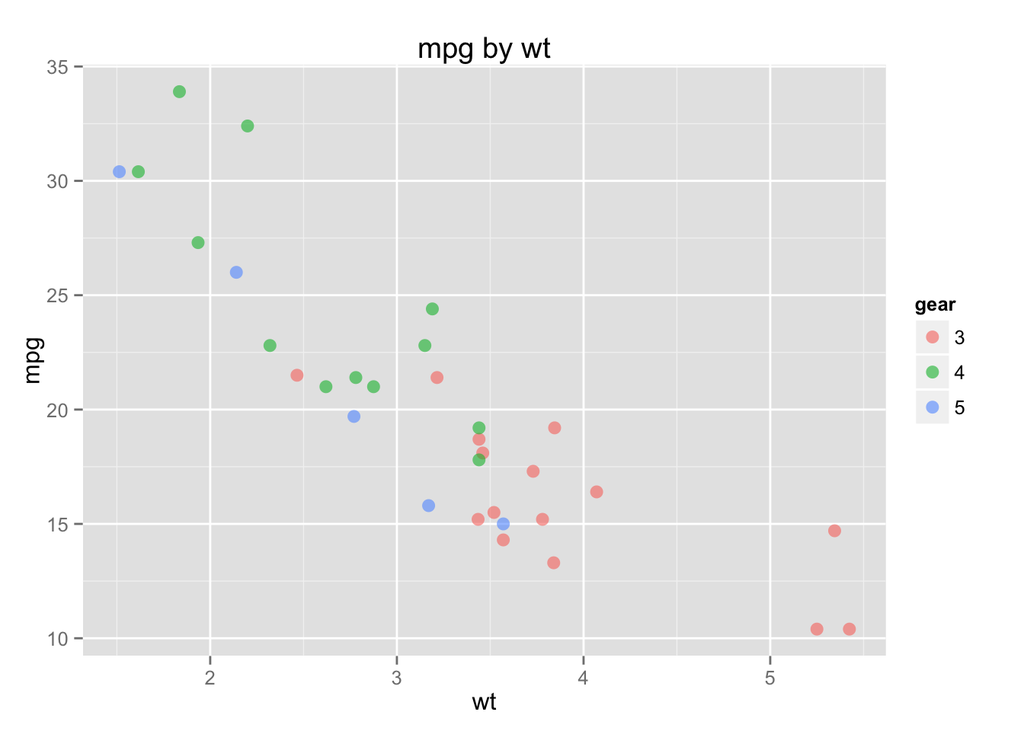

```r
qplot(x=wt, y=mpg, data=mtcars, color=gear, geom=c("point"),main="mpg by wt", ,size=I(3),alpha=I(0.6))
```

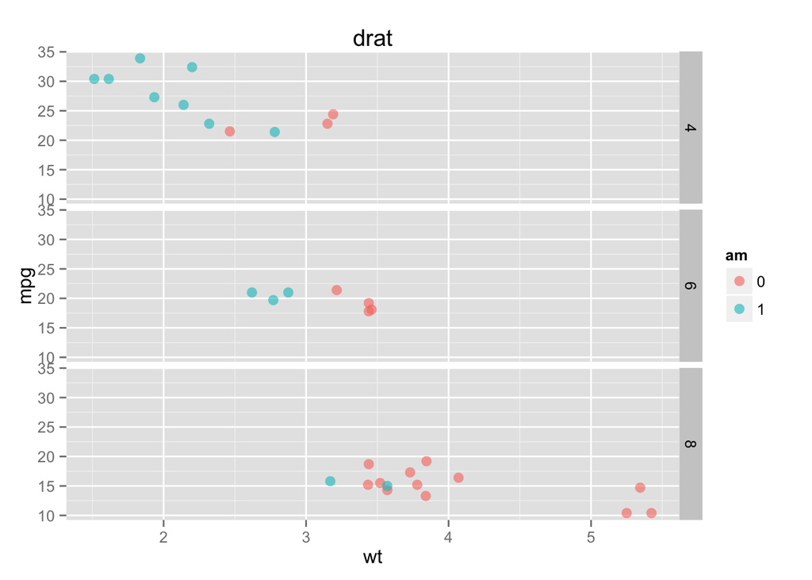

```r
qplot(x=wt, y=mpg, data=mtcars, color=am, geom=c("point"),main="drat", facets=cyl~.,size=I(3),alpha=I(0.6))
```

3. Regression y=mpg on x= am and wt; Interpret coefficients

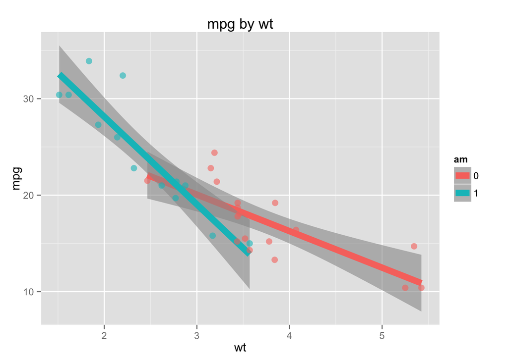

```r
qplot(x=wt,y=mpg,data=mtcars,color=am, geom=c("smooth","point"),method='lm',formula= y~ x ,main="mpg by wt", ,size=I(3),alpha=I(0.6))
```

Actual linear model is

```r
fit<-lm(formula=mpg ~ wt + am, data=mtcars)
fit$coefficient
```

```
## (Intercept)          wt         am1
## 37.32155131 -5.35281145 -0.02361522
```

```r
summary(fit)
```

```
##
## Call:
## lm(formula = mpg ~ wt + am, data = mtcars)
##
## Residuals:
##     Min      1Q  Median      3Q     Max
## -4.5295 -2.3619 -0.1317  1.4025  6.8782
##
## Coefficients:
##             Estimate Std. Error t value Pr(>|t|)
## (Intercept) 37.32155    3.05464  12.218 5.84e-13 ***
## wt          -5.35281    0.78824  -6.791 1.87e-07 ***
## am1         -0.02362    1.54565  -0.015    0.988
## ---
## Signif. codes:  0 '***' 0.001 '**' 0.01 '*' 0.05 '.' 0.1 ' ' 1
##
## Residual standard error: 3.098 on 29 degrees of freedom
## Multiple R-squared:  0.7528, Adjusted R-squared:  0.7358
## F-statistic: 44.17 on 2 and 29 DF,  p-value: 1.579e-09
```

The regression tells us that at at zero weight, the mpg is 37, and that as weight increases, the mpg falls steeply. Having am=1 decreases fuel efficiently very slightly. However this is not at all significant. Look at residuals to find some other explanatory variable.

4. Look at residuals. We deliberately left out many of the variables available when regressing on fuel efficiency in mpg. Here we will check the residualas to see if these variables actually do have something to offer to the regression model. If there is no obvious pattern in the residuals by these other variables, then it is appropriate to keep them out of the model. Residuals with patterns:

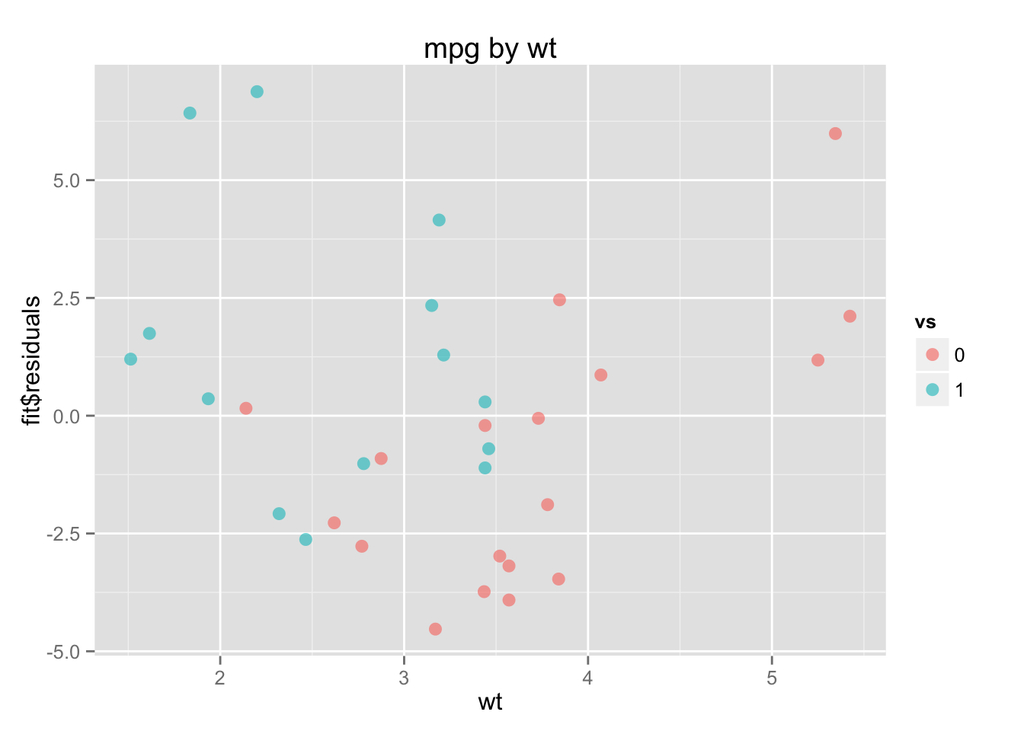

```r
qplot(x=wt, y=fit$residuals, data=mtcars,color=vs, geom=c("point"),main="mpg by wt", ,size=I(3),alpha=I(0.6))
```

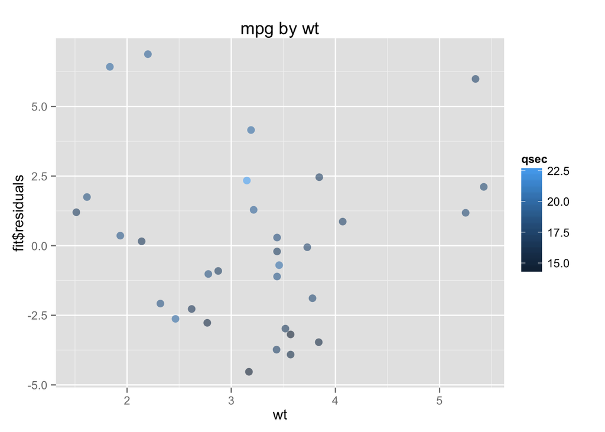

```r
qplot(x=wt, y=fit$residuals, data=mtcars,color=qsec, geom=c("point"),main="mpg by wt", ,size=I(3),alpha=I(0.6))
```

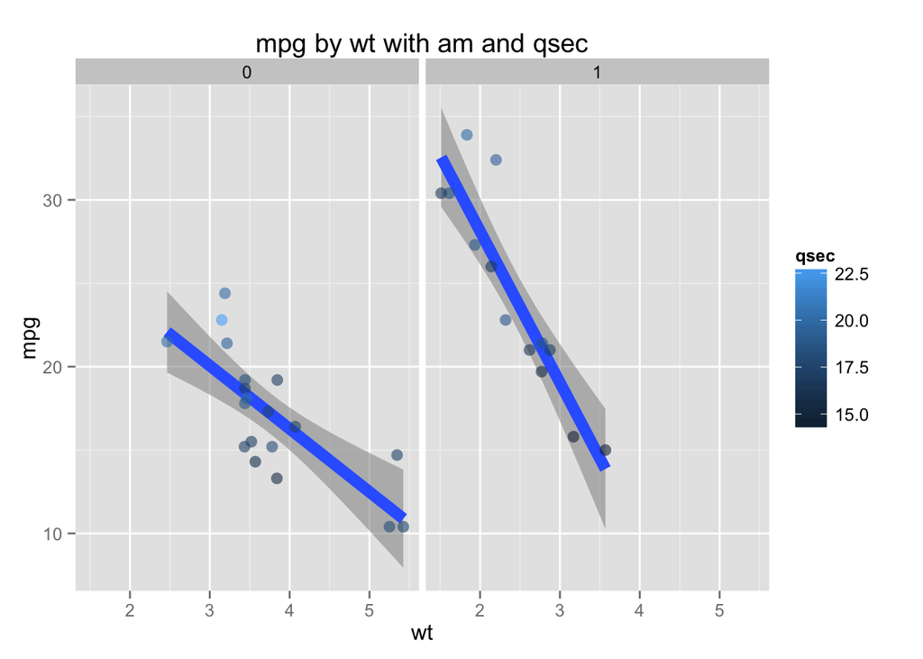

```r
qplot(x=wt,y=mpg,data=mtcars,color=qsec, geom=c("smooth","point"),method='lm',formula= y~ x ,main="mpg by wt with am and qsec", facets=.~am,size=I(3),alpha=I(0.6))
```

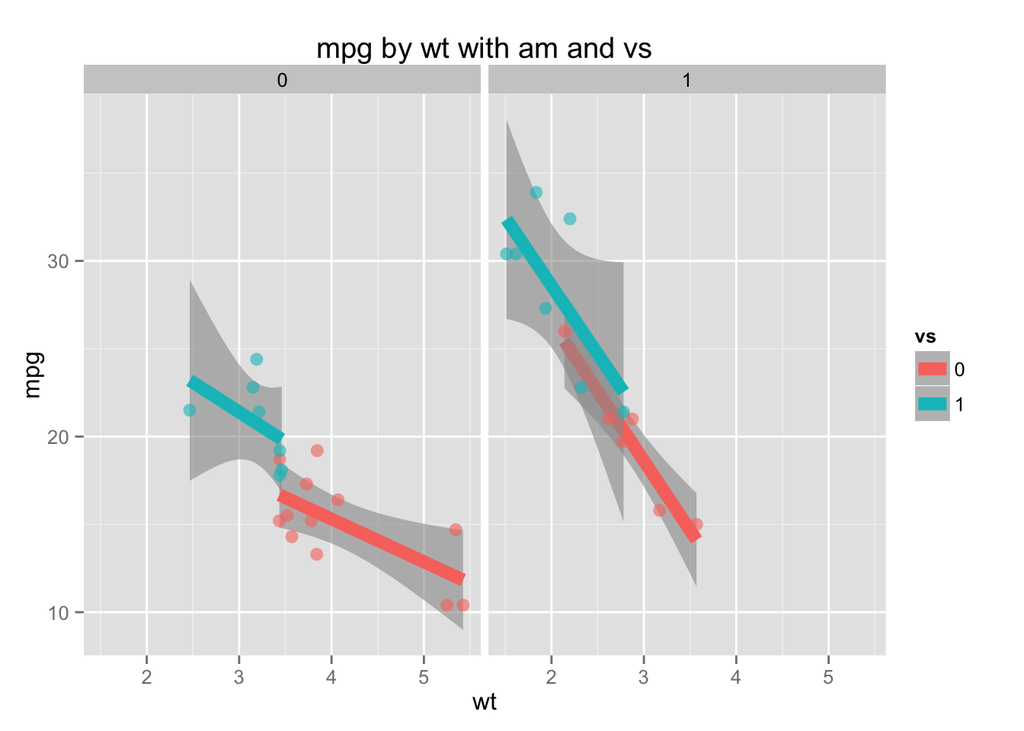

```r
qplot(x=wt,y=mpg,data=mtcars,color=vs, geom=c("smooth","point"),method='lm',formula= y~ x ,main="mpg by wt with am and vs", facets=.~am,size=I(3),alpha=I(0.6))
```

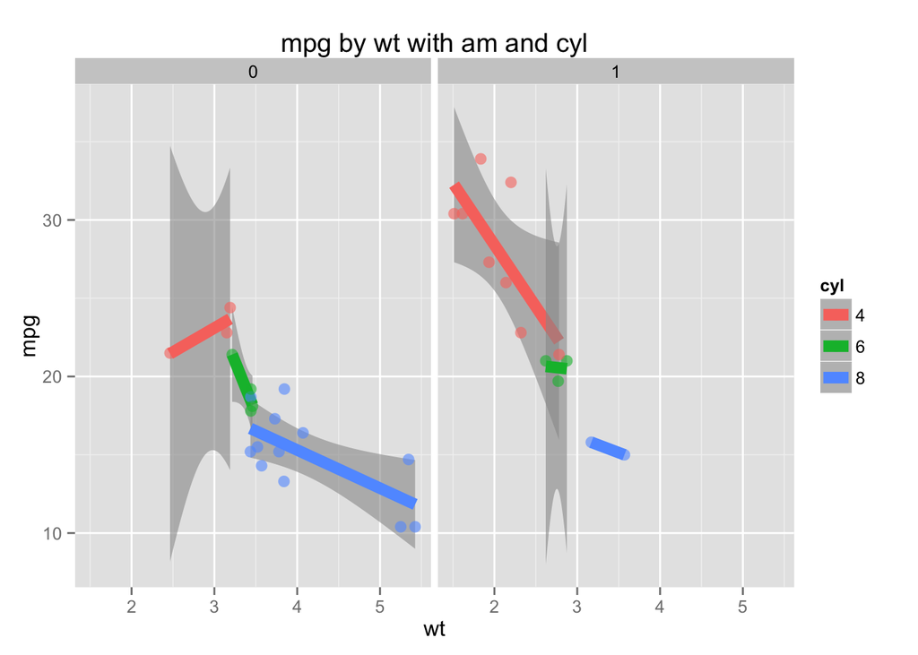

```r
qplot(x=wt,y=mpg,data=mtcars,color=cyl, geom=c("smooth","point"),method='lm',formula= y~ x ,main="mpg by wt with am and cyl", facets=.~am,size=I(3),alpha=I(0.6))
```

Actual linear model is

```r
fit1<-lm(formula=mpg ~ wt + am + qsec, data=mtcars)
fit1$coefficient
```

```
## (Intercept)          wt         am1        qsec
##    9.617781   -3.916504    2.935837    1.225886
```

```r
fit2<-lm(formula=mpg ~ wt + am + vs, data=mtcars)
fit2$coefficient
```

```
## (Intercept)          wt         am1         vs1
##   30.078722   -3.784454    1.491345    3.615040
```

```r
fit3<-lm(formula=mpg ~ wt + am + cyl, data=mtcars)
fit3$coefficient
```

```
## (Intercept)          wt         am1        cyl6        cyl8
##  33.7535920  -3.1495978   0.1501031  -4.2573185  -6.0791189
```

```r
fit4<-lm(formula=mpg ~ wt + am + hp, data=mtcars)
fit4$coefficient
```

```
## (Intercept)          wt         am1          hp
## 34.00287512 -2.87857541  2.08371013 -0.03747873
```

```r
summary(fit1)
```

```
##
## Call:
## lm(formula = mpg ~ wt + am + qsec, data = mtcars)
##
## Residuals:
##     Min      1Q  Median      3Q     Max
## -3.4811 -1.5555 -0.7257  1.4110  4.6610
##
## Coefficients:
##             Estimate Std. Error t value Pr(>|t|)
## (Intercept)   9.6178     6.9596   1.382 0.177915
## wt           -3.9165     0.7112  -5.507 6.95e-06 ***
## am1           2.9358     1.4109   2.081 0.046716 *
## qsec          1.2259     0.2887   4.247 0.000216 ***
## ---
## Signif. codes:  0 '***' 0.001 '**' 0.01 '*' 0.05 '.' 0.1 ' ' 1
##
## Residual standard error: 2.459 on 28 degrees of freedom
## Multiple R-squared:  0.8497, Adjusted R-squared:  0.8336
## F-statistic: 52.75 on 3 and 28 DF,  p-value: 1.21e-11
```

```r
summary(fit2)
```

```
##
## Call:
## lm(formula = mpg ~ wt + am + vs, data = mtcars)
##
## Residuals:
##     Min      1Q  Median      3Q     Max
## -3.7733 -2.2519 -0.3445  1.4129  5.6594
##
## Coefficients:
##             Estimate Std. Error t value Pr(>|t|)
## (Intercept)  30.0787     3.7480   8.025 9.71e-09 ***
## wt           -3.7845     0.8981  -4.214 0.000236 ***
## am1           1.4913     1.4863   1.003 0.324262
## vs1           3.6150     1.2761   2.833 0.008454 **
## ---
## Signif. codes:  0 '***' 0.001 '**' 0.01 '*' 0.05 '.' 0.1 ' ' 1
##
## Residual standard error: 2.779 on 28 degrees of freedom
## Multiple R-squared:  0.8079, Adjusted R-squared:  0.7873
## F-statistic: 39.25 on 3 and 28 DF,  p-value: 3.659e-10
```

```r
summary(fit3)
```

```
##
## Call:
## lm(formula = mpg ~ wt + am + cyl, data = mtcars)
##
## Residuals:
##     Min      1Q  Median      3Q     Max
## -4.4898 -1.3116 -0.5039  1.4162  5.7758
##
## Coefficients:
##             Estimate Std. Error t value Pr(>|t|)
## (Intercept)  33.7536     2.8135  11.997  2.5e-12 ***
## wt           -3.1496     0.9080  -3.469  0.00177 **
## am1           0.1501     1.3002   0.115  0.90895
## cyl6         -4.2573     1.4112  -3.017  0.00551 **
## cyl8         -6.0791     1.6837  -3.611  0.00123 **
## ---
## Signif. codes:  0 '***' 0.001 '**' 0.01 '*' 0.05 '.' 0.1 ' ' 1
##
## Residual standard error: 2.603 on 27 degrees of freedom
## Multiple R-squared:  0.8375, Adjusted R-squared:  0.8134
## F-statistic: 34.79 on 4 and 27 DF,  p-value: 2.73e-10
```

```r
summary(fit4)
```

```
##
## Call:
## lm(formula = mpg ~ wt + am + hp, data = mtcars)
##
## Residuals:
##     Min      1Q  Median      3Q     Max
## -3.4221 -1.7924 -0.3788  1.2249  5.5317
##
## Coefficients:
##              Estimate Std. Error t value Pr(>|t|)
## (Intercept) 34.002875   2.642659  12.867 2.82e-13 ***
## wt          -2.878575   0.904971  -3.181 0.003574 **
## am1          2.083710   1.376420   1.514 0.141268
## hp          -0.037479   0.009605  -3.902 0.000546 ***
## ---
## Signif. codes:  0 '***' 0.001 '**' 0.01 '*' 0.05 '.' 0.1 ' ' 1
##
## Residual standard error: 2.538 on 28 degrees of freedom
## Multiple R-squared:  0.8399, Adjusted R-squared:  0.8227
## F-statistic: 48.96 on 3 and 28 DF,  p-value: 2.908e-11
```

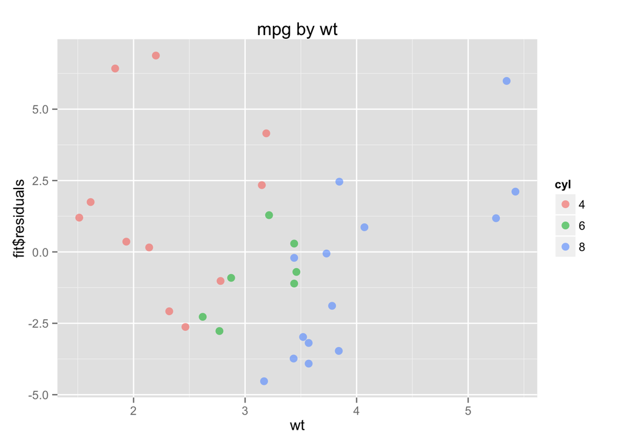

```r
qplot(x=wt, y=fit$residuals, data=mtcars,color=cyl, geom=c("point"),main="mpg by wt", ,size=I(3),alpha=I(0.6))
```

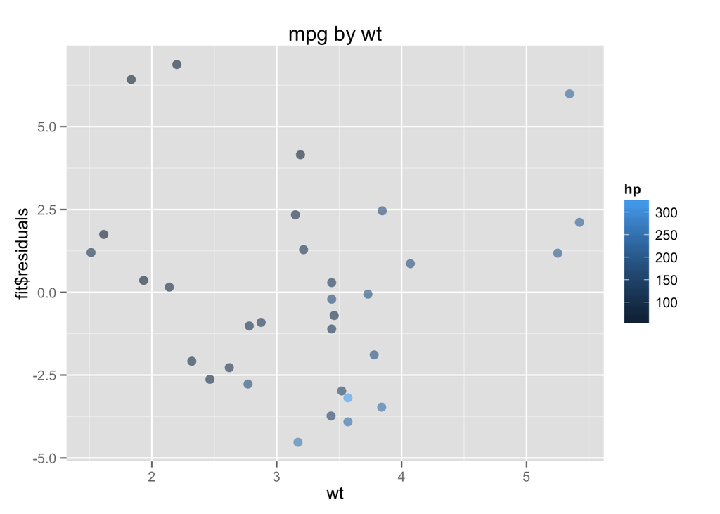

```r
qplot(x=wt, y=fit$residuals, data=mtcars,color=hp, geom=c("point"),main="mpg by wt", ,size=I(3),alpha=I(0.6))
```

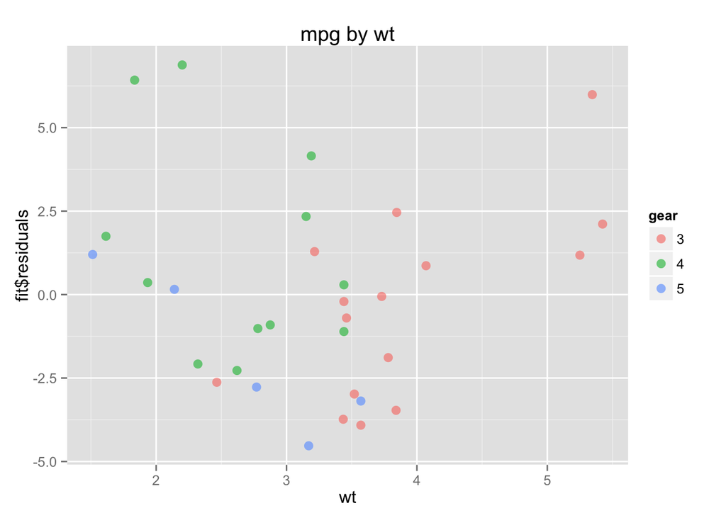

```r
qplot(x=wt, y=fit$residuals, data=mtcars,color=gear, geom=c("point"),main="mpg by wt", ,size=I(3),alpha=I(0.6))
```

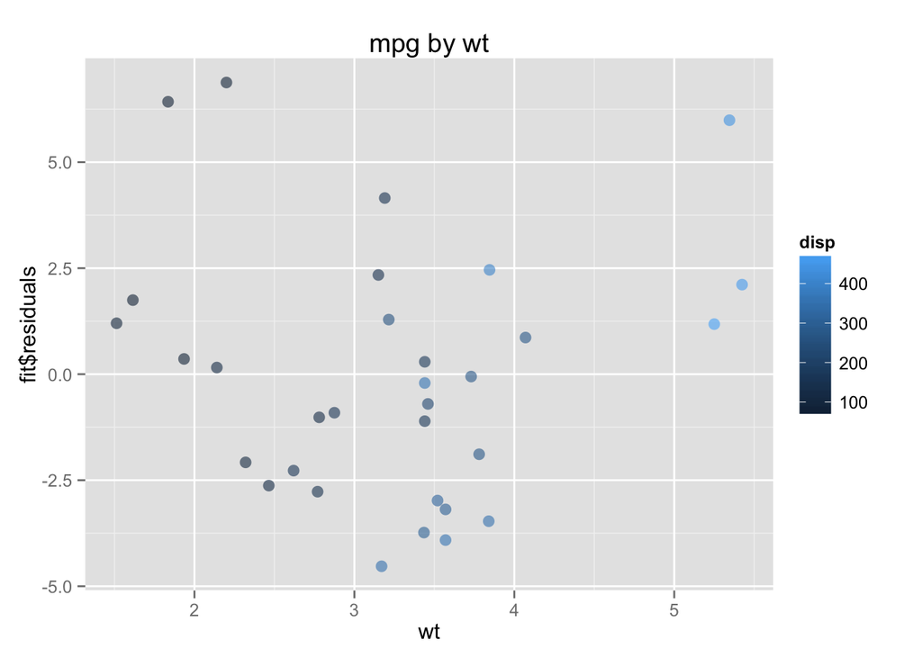

```r
qplot(x=wt, y=fit$residuals, data=mtcars,color=disp, geom=c("point"),main="mpg by wt", ,size=I(3),alpha=I(0.6))
```

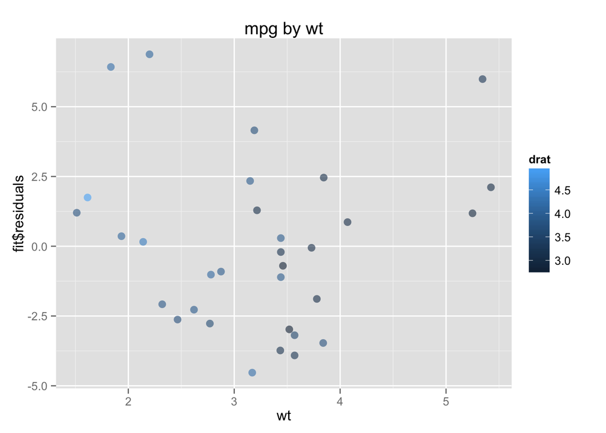

```r
qplot(x=wt, y=fit$residuals, data=mtcars,color=drat, geom=c("point"),main="mpg by wt", ,size=I(3),alpha=I(0.6))
```

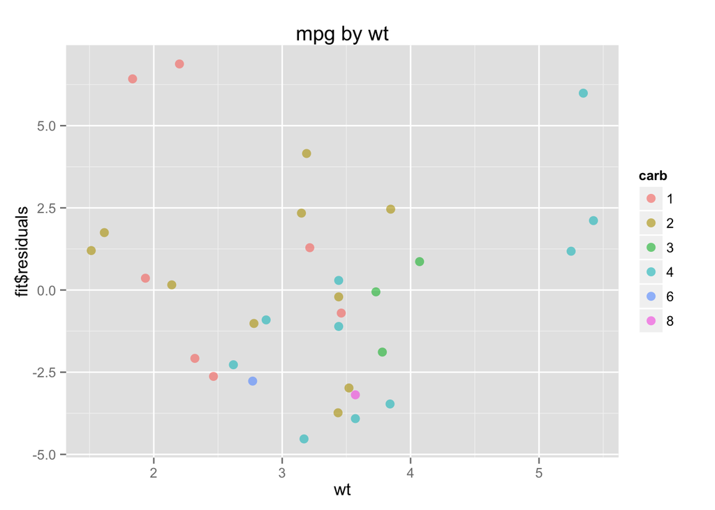

```r
qplot(x=wt, y=fit$residuals, data=mtcars,color=carb, geom=c("point"),main="mpg by wt", ,size=I(3),alpha=I(0.6))
```